# Bayesian modeling and prediction for movies

## Setup

Load required packages and data.

```r
library(ggplot2)
library(dplyr)
library(statsr)
library(BAS)
library(patchwork)
```

```r
load("movies.Rdata")
```

## 1. Data

The data contains details about 651 movies that were made between 1970 and 2014. There are a large number of variables which are given below.

```r
names(movies)
```

```
##  [1] "title"            "title_type"       "genre"            "runtime"
##  [5] "mpaa_rating"      "studio"           "thtr_rel_year"    "thtr_rel_month"
##  [9] "thtr_rel_day"     "dvd_rel_year"     "dvd_rel_month"    "dvd_rel_day"
## [13] "imdb_rating"      "imdb_num_votes"   "critics_rating"   "critics_score"
## [17] "audience_rating"  "audience_score"   "best_pic_nom"     "best_pic_win"
## [21] "best_actor_win"   "best_actress_win" "best_dir_win"     "top200_box"
## [25] "director"         "actor1"           "actor2"           "actor3"
## [29] "actor4"           "actor5"           "imdb_url"         "rt_url"
```

The data has been randomly sampled. Therefore, the results are **generalizable**. The total number of 651 movies is good enough.

There is no random assignment because this is an observational data set. Therefore, **No causal** relationships can be inferred. Only associations and correlations can be inferred.

## 2. Data manipulation

In this section, a new set of variables will be created.

Variable **feature_film** designates whether the *title_type* is “Feature Film” or not.

```r
movies <- movies %>% mutate(feature_film =
                    ifelse(title_type == "Feature Film", "yes", "no"))
movies$feature_film <- as.factor(movies$feature_film)
```

The new variable **drama** designates whether the movie’s *genre* is “drama” or not.

```r
movies <- movies %>% mutate(drama =
                    ifelse(genre == "Drama", "yes", "no"))

movies$drama <- as.factor(movies$drama)
```

The new variable **mpaa_rating_R** based on *mpaa_rating* signifies whether the movies is “R” rated or not.

```r
movies <- movies %>% mutate(mpaa_rating_R =
                              ifelse(mpaa_rating == "R", "yes", "no"))

movies$mpaa_rating_R <- as.factor(movies$mpaa_rating_R)
```

The variables **oscar_season** and **summer_season** are based on the variable *thtr_rel_month*.

```r
movies <- movies %>% mutate(oscar_season =
                            ifelse(thtr_rel_month == 12 | thtr_rel_month == 11 |
                                   thtr_rel_month == 10, "yes", "no"))

movies$oscar_season <- as.factor(movies$oscar_season)

movies <- movies %>% mutate(summer_season =
                            ifelse(thtr_rel_month == 5 | thtr_rel_month == 6 |
                                   thtr_rel_month == 7 | thtr_rel_month == 8,
                                   "yes", "no"))

movies$summer_season <- as.factor(movies$summer_season)
```

Let us remove all “NA” values before proceeding.

```r
movies <- na.omit(movies)
```

## 3. Exploratory data analysis

The aim of this project is to create a Bayesian regression model for predicting **audience_score** from the provided and above created variables. Therefore, in this section, relationships between some of the variables and the **audience_score** will be assessed.

### 3.1 Plots of possible relationships

Let us look at the association between the **audience_score** and the **critics_score**.

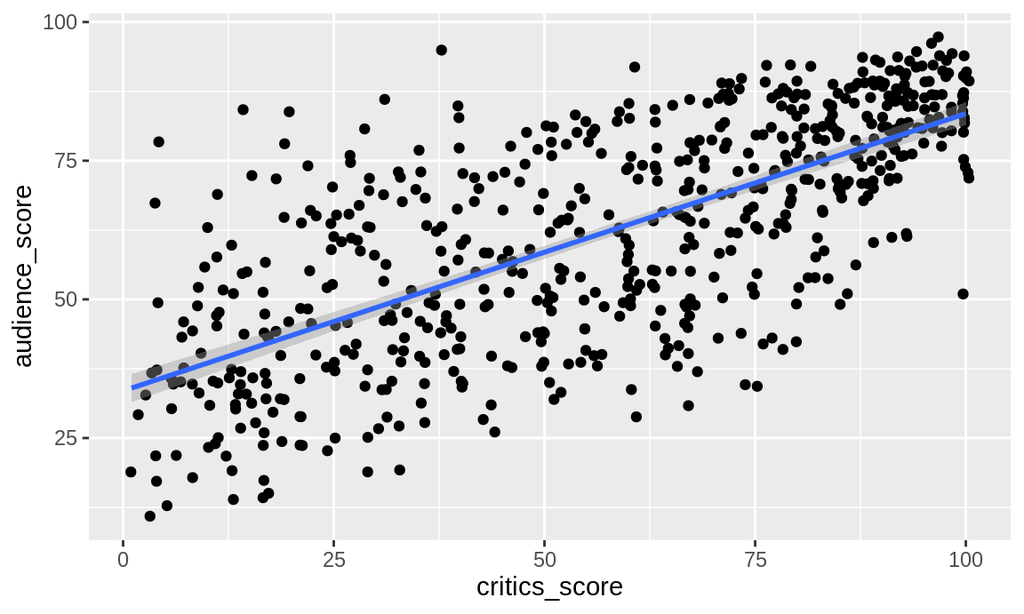

```r
ggplot(data = movies, aes(x = critics_score, y = audience_score)) +
  geom_jitter() + geom_smooth(method = "lm")
```

The relationship between the two variables appear to be positive and associative.

Now let us look at the **audience_score** and **imdb_rating**.

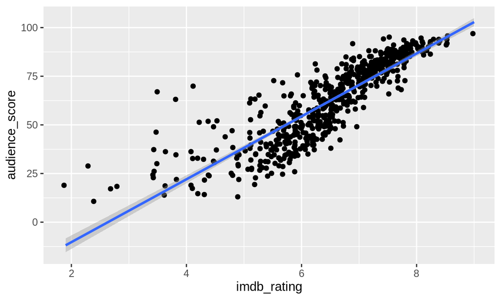

```r
ggplot(data = movies, aes(x = imdb_rating, y = audience_score)) +
  geom_jitter() + geom_smooth(method = "lm")
```

This too appears to be a strong predictor of the **audience_score**. The data points appear to be clumped up closely around the regression line.

The relationship between the **audience_score** and the **runtime** is as follows.

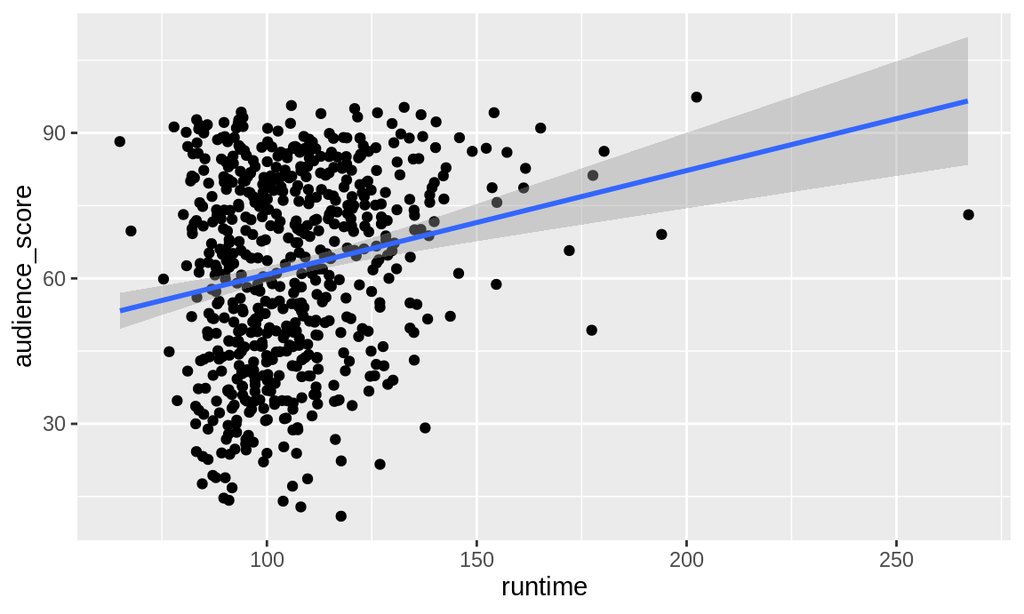

```r
ggplot(data = movies, aes(x = runtime, y = audience_score)) +
  geom_jitter() + geom_smooth(method = "lm")
```

**runtime** appears to be a weak predictor. Almost all of the points are roughly between 75 and 150.

The relationship between **genre** and **audience_score** is given below.

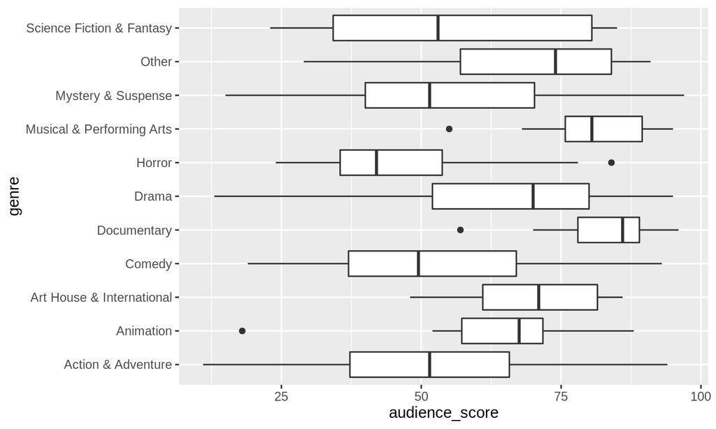

```r
ggplot(data = movies, aes(x = genre, y = audience_score)) +
  geom_boxplot() + coord_flip()
```

**audience_score** appears to be dependent on the **genre** variable. This is because the median audience score changes with respect to the genre. Also, there appears to be some outliers in some genres.

The following boxplot depicts the association between **oscar_season** and **audience_score**.

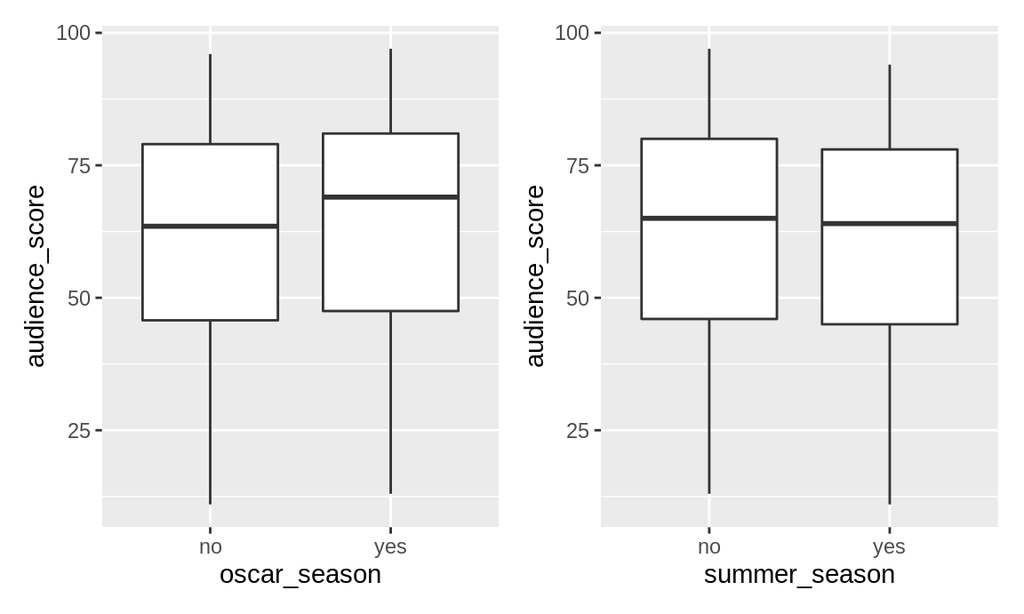

```r
a <- ggplot(data = movies) + geom_boxplot(aes(x = oscar_season, y = audience_score))
b <- ggplot(data = movies) + geom_boxplot(aes(x = summer_season, y = audience_score))

# Need patchwork package for this.
a + b
```

It appears that movies released in the Oscar season have higher median audience scores compared to the rest. In contrast, movies released in the summer season have lower median audience scores.

### 3.2 Summary statistics

The summary of **runtime**, **imdb_rating**, and **audience_score** are given as follows.

```r
summary(movies$runtime)
```

```
##    Min. 1st Qu.  Median    Mean 3rd Qu.    Max.
##    65.0    93.0   103.0   106.5   116.0   267.0
```

```r
summary(movies$imdb_rating)
```

```
##    Min. 1st Qu.  Median    Mean 3rd Qu.    Max.
##   1.900   5.900   6.600   6.486   7.300   9.000
```

```r
summary(movies$audience_score)
```

```
##    Min. 1st Qu.  Median    Mean 3rd Qu.    Max.
##   11.00   46.00   65.00   62.21   80.00   97.00
```

The mean runtime of a movie is 106.5 minutes, whereas the average audience score is 62.21. The average imdb rating is 6.49.

Let us calculate some summaries related to categorical variables.

```r
summary(movies$title_type)
```

```
##  Documentary Feature Film     TV Movie
##           42          573            4
```

Majority of the movies are feature films with 573. This is more than 90% of all the movies in the sample.

```r
summary(movies$genre)
```

```
##        Action & Adventure                 Animation Art House & International
##                        62                         8                        12
##                    Comedy               Documentary                     Drama
##                        86                        40                       298
##                    Horror Musical & Performing Arts        Mystery & Suspense
##                        22                        12                        56
##                     Other Science Fiction & Fantasy
##                        15                         8
```

With respect to genre, the first place take drama category followed by comedy. Animation movies are the least.

## 4. Modeling

Let us create the ensemble of models.

```r
mov_model <- bas.lm(audience_score ~ drama + runtime + mpaa_rating_R +
                    thtr_rel_year + oscar_season + summer_season + imdb_rating +
                    imdb_num_votes + critics_score + best_pic_nom + best_pic_win +
                    best_actor_win + best_actress_win + best_dir_win + top200_box,
                    data = movies, prior = "ZS-null", modelprior = uniform(),
                    method = "MCMC")
```

### 4.1 Model diagnostics

The following plot depicts the posterior inclusion probabilities for predictors using relative Monte Carlo frequencies of the sampled models (y axis) vs. the re-normalized marginal likelihoods multiplied by the priors (x axis) of discovered unique MCMC samples.

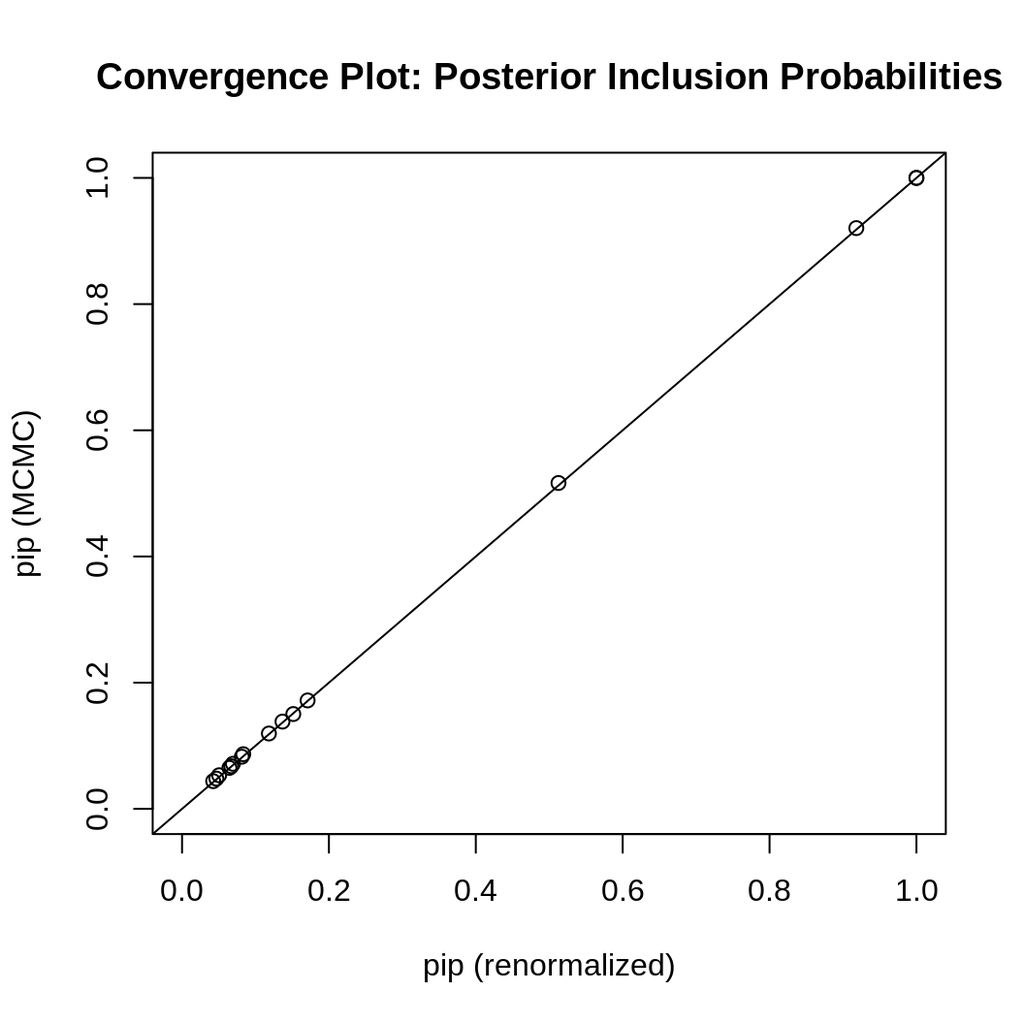

```r
diagnostics(mov_model, type = "pip")
```

As the two sets are in agreement, we can conclude that we have carried out MCMC process correctly.

The plot below depicts residuals vs. fitted values. The fitted values have been obtained from Bayesian Model Averaging.

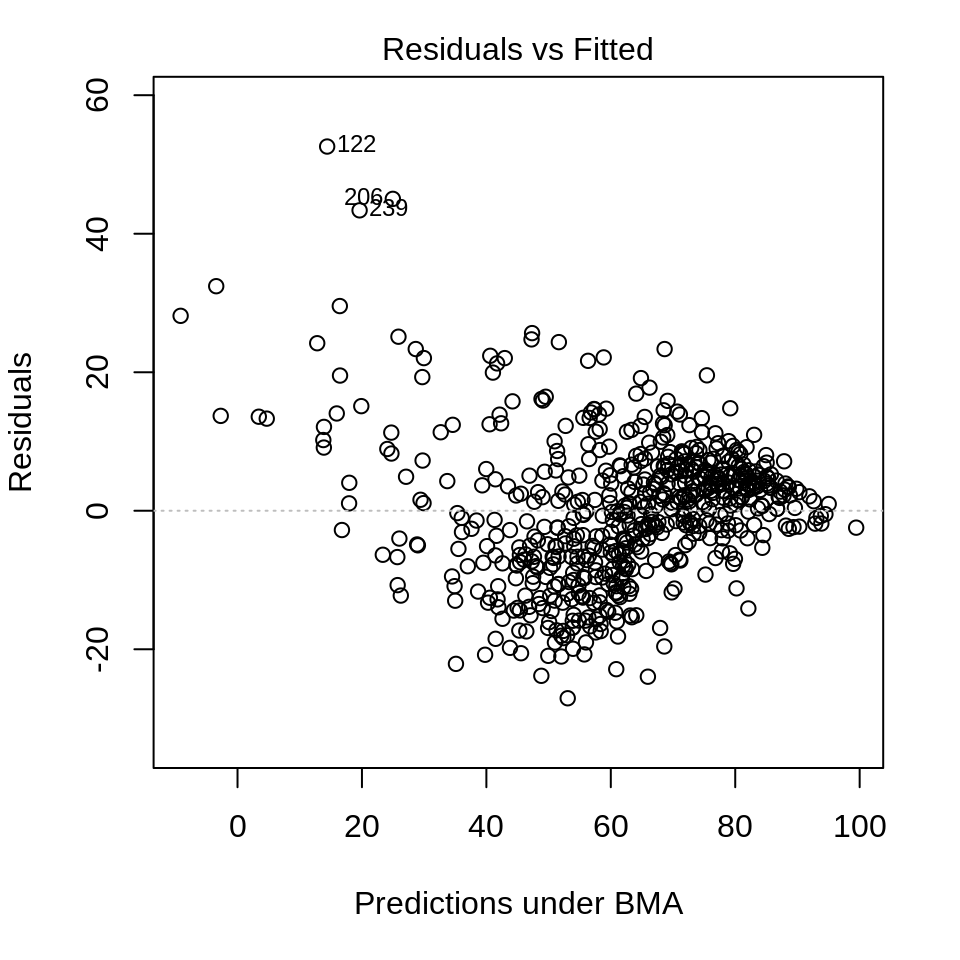

```r
# 'par' sets graphics parameters in 'base'. 'mar' is margins (bottom, left, top, right)
par(mar = c(5, 4, 2, 2))

# ' sub.caption = "" ' removes the annoying line of text below x axis.
plot(mov_model, which = 1, add.smooth = F, sub.caption = "")
```

There appear to be some outliers. The variability seems to be uniform in the middle section of the x axis, but shows non-uniformity in the either ends.

The following plot illustrates the cumulative probabilities of the models for each selected MCMC model.

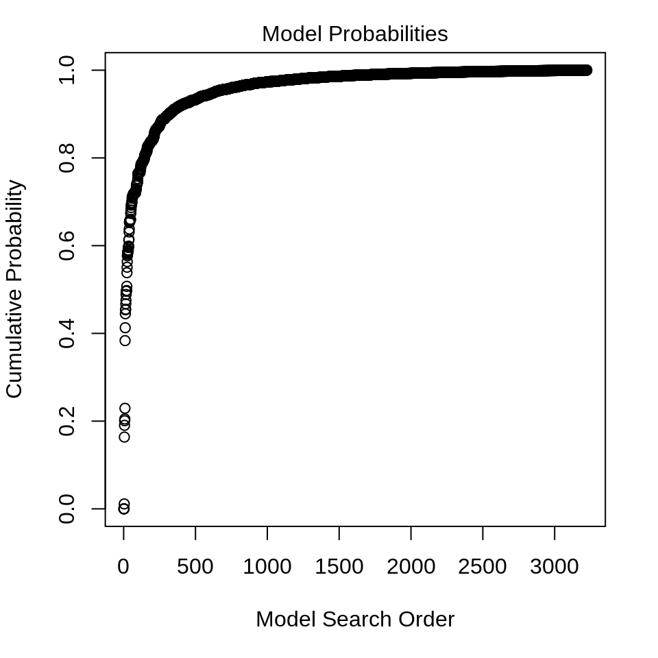

```r
par(mar = c(5, 4, 2, 2))
plot(mov_model, which = 2, add.smooth = F, sub.caption = "")
```

It is clear that we have reached the maximum cumulative probability of 1 by using approximately 2000 MCMC models.

Following figure shows the log of marginal likelihood vs. the size of the model.

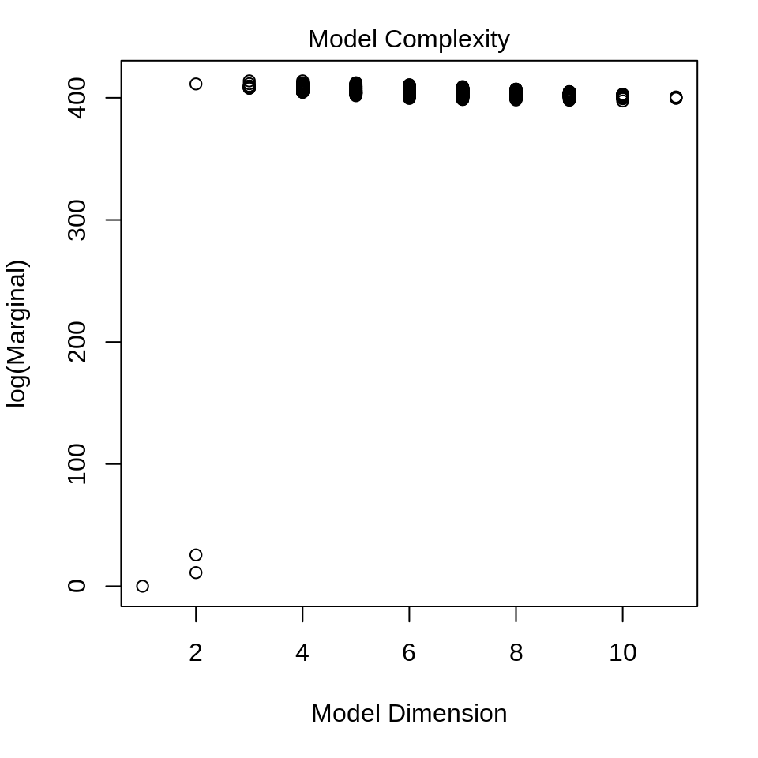

```r
par(mar = c(5, 4, 2, 2))
plot(mov_model, which = 3, add.smooth = F, sub.caption = "")
```

Some of the models with highest marginal likelihoods have between 3 to 11 predictors.

The inclusion probabilities of the predictors are given in the following plot. This shows the importance of different parameters. The pink lines show the marginal inclusion probabilities greater than 0.5.

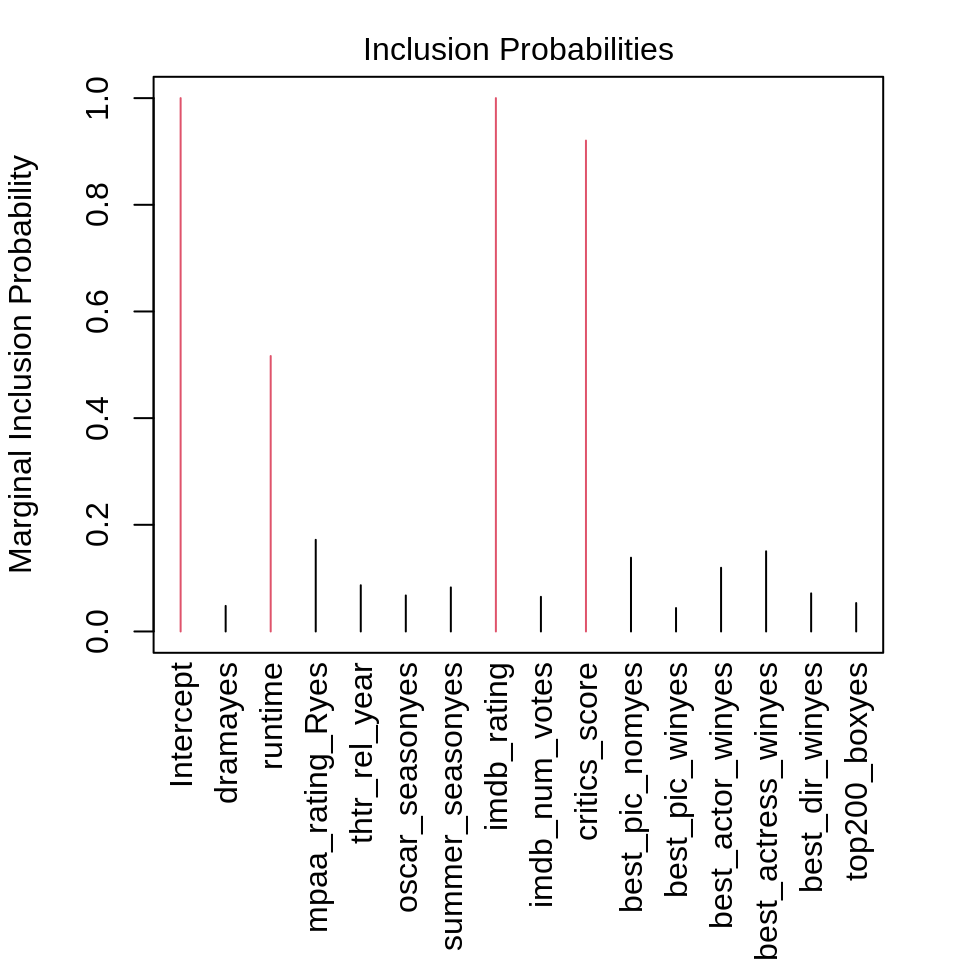

```r
par(mar = c(8, 4, 2, 2))
plot(mov_model, which = 4, add.smooth = F, sub.caption = "")
```

Intercept has a 100% probability of being included and this is the expected behavior. Other important predictors are **runtime**, **imdb_rating**, and **critics_score**.

The image of the model space is given below.

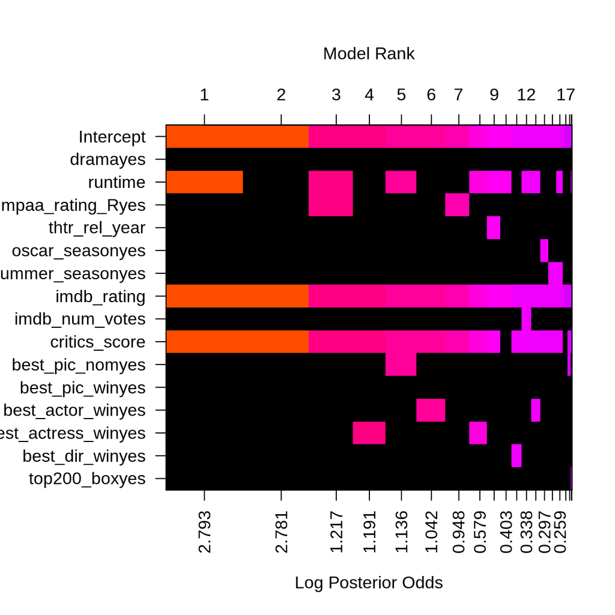

```r
image(mov_model, rotate = F, plas = 3)
```

The best model (given by index 1) has **runtime**, **imdb_rating**, and **critics_score** as predictors. These three variables seem like the most frequently present predictors in the top 20 models.

### 4.2 Model coefficients

Let us start by extracting the coefficients of the predictors.

```r
mov_coefs <- coef(mov_model)
mov_coefs
```

```
##
##  Marginal Posterior Summaries of Coefficients:
##
##  Using  BMA
##
##  Based on the top  3224 models
##                      post mean   post SD     post p(B != 0)
## Intercept             6.221e+01   4.087e-01   1.000e+00
## dramayes              2.050e-02   2.120e-01   4.789e-02
## runtime              -3.059e-02   3.401e-02   5.164e-01
## mpaa_rating_Ryes     -2.513e-01   6.478e-01   1.718e-01
## thtr_rel_year        -4.131e-03   1.762e-02   8.664e-02
## oscar_seasonyes      -6.403e-02   3.454e-01   6.750e-02
## summer_seasonyes      8.914e-02   3.927e-01   8.259e-02
## imdb_rating           1.488e+01   7.396e-01   1.000e+00
## imdb_num_votes        2.554e-07   1.460e-06   6.493e-02
## critics_score         6.950e-02   2.966e-02   9.204e-01
## best_pic_nomyes       5.393e-01   1.622e+00   1.383e-01
## best_pic_winyes      -8.699e-03   9.052e-01   4.391e-02
## best_actor_winyes    -2.173e-01   7.248e-01   1.194e-01
## best_actress_winyes  -3.376e-01   9.540e-01   1.503e-01
## best_dir_winyes      -1.260e-01   6.433e-01   7.142e-02
## top200_boxyes         9.715e-02   7.510e-01   5.325e-02
```

The coefficient of **imdb_rating** has a marginal posterior probability of not being 0 of 1.000. This means that this variable is the strongest predictor of **audience_score**.

Let us plot the coefficients of strong predictors. These plots are the posterior distributions of the coefficients of the variables.

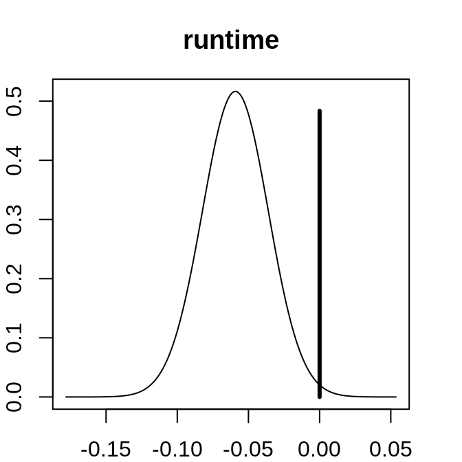

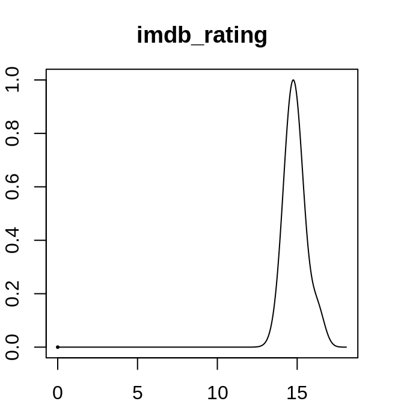

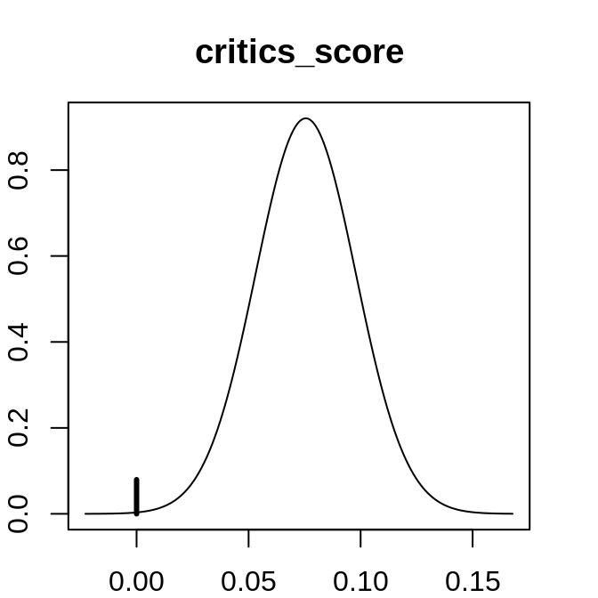

```r
par(mar = c(2,2,3,2))
plot(mov_coefs, subset = c(3, 8, 10), ask = F)
```

The probability of **runtime** being 0 is around 50%, whereas that of **imdb_rating** is nearly zero. For **critics_score**, this probability is about 10%. The range of values for the posterior probability of **imdb_rating** is far from zero, indicating that this is a very strong predictor of **audience_score**.

Let us look at some weak predictors now.

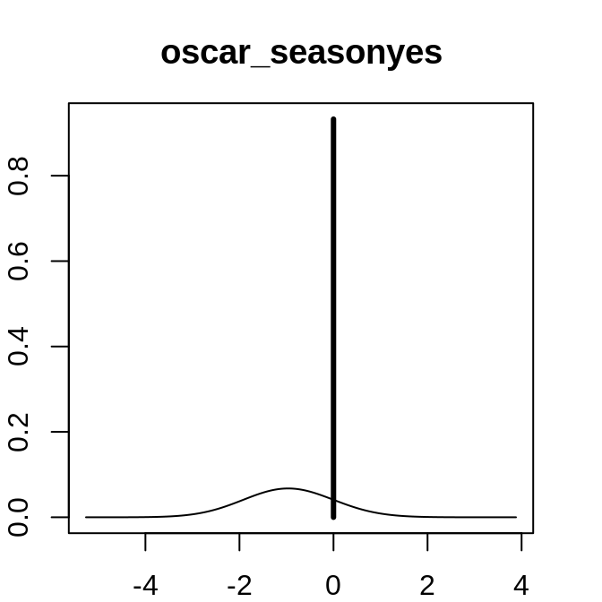

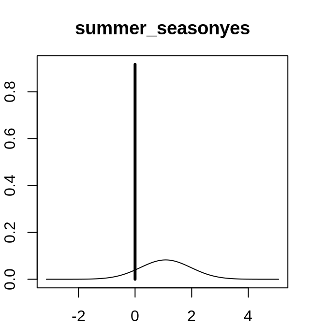

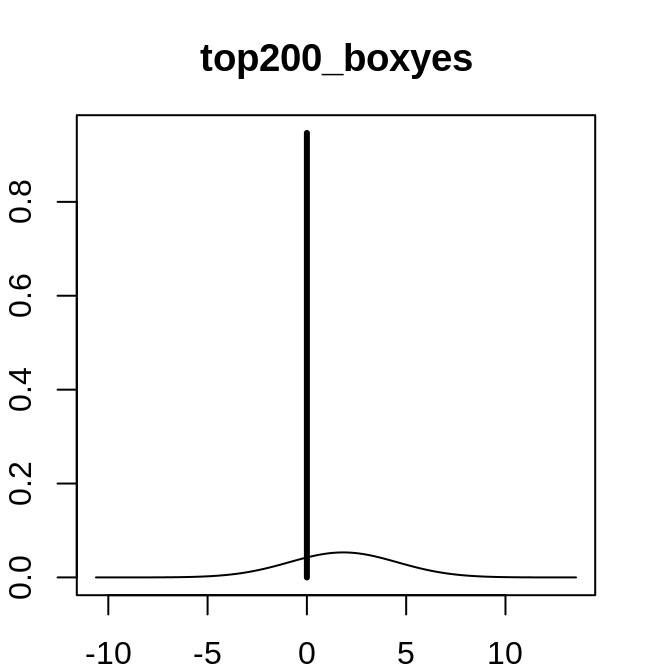

```r
par(mar = c(2,2,3,2))
plot(mov_coefs, subset = c(6, 7, 16), ask = F)
```

All three of these variables have posterior probabilities of being 0 above 80%. Furthermore, the range of their spread contains 0. Therefore, they are weak predictors.

#### 4.2.1 Intrepretation

We can interpret the model coefficient by using the posterior mean of the coefficient which would be used for predictions. This interpretation would be similar to the interpretation of the model coefficient in ordinary linear regression (OLS).

For example, the coefficient of **imdb_rating** is 14.89. This means, all else being held constant, for each point of **imdb_rating**, the model would predict the **audience_score** to increase by 14.89.

Similar interpretations can be provided for other predictor’s coefficients.

### 4.3 Credible interals of predictors

The predictor’s credible intervals can be calculated as follows.

```r
round(confint(mov_coefs), 2)
```

```
##                      2.5% 97.5%  beta
## Intercept           61.42 63.00 62.21
## dramayes             0.00  0.00  0.02
## runtime             -0.09  0.00 -0.03
## mpaa_rating_Ryes    -2.02  0.00 -0.25
## thtr_rel_year       -0.05  0.00  0.00
## oscar_seasonyes     -0.82  0.03 -0.06
## summer_seasonyes    -0.02  1.01  0.09
## imdb_rating         13.51 16.48 14.88
## imdb_num_votes       0.00  0.00  0.00
## critics_score        0.00  0.11  0.07
## best_pic_nomyes      0.00  5.03  0.54
## best_pic_winyes      0.00  0.00 -0.01
## best_actor_winyes   -2.31  0.00 -0.22
## best_actress_winyes -2.95  0.00 -0.34
## best_dir_winyes     -1.44  0.00 -0.13
## top200_boxyes       -0.50  0.22  0.10
## attr(,"Probability")
## [1] 0.95
## attr(,"class")
## [1] "confint.bas"
```

## 5. Prediction

As our aim is to provide a good prediction about a chosen movie from 2016, we should obtains the Best Predictive Model (BPM) from the Bayesian Model Averaging. Let us do this.

```r
mov_bpm <- predict(mov_model, estimator = "BPM")
mov_bpm$best.vars
```

```
## [1] "Intercept"     "runtime"       "imdb_rating"   "critics_score"
```

It is interesting, but not surprising, to see that this model only includes the the best predictive variables as discussed under section 4.2.

The chosen movies from the year 2016 is “Nerve”. The data came from the link: https://www.rottentomatoes.com/m/nerve_2016. Let us create a new data frame for this movie.

```r
nerve <- data.frame(mpaa_rating_R = "no", runtime = 96, critics_score = 66,
                    top200_box = "no", best_pic_nom = "no", best_pic_win = "no",
                    best_actor_win = "no", best_actress_win = "no", best_dir_win = "no",
                    drama = "no", feature_film = "yes", thtr_rel_year = 2016,
                    oscar_season = "no", summer_season = "yes", imdb_rating = 6.5,
                    imdb_num_votes = 120790)
```

Let us carry out the actual prediction.

```r
nerve_pred <- predict(mov_model, newdata = nerve, estimator = "BPM", se.fit = T)
nerve_pred$fit
```

[output not shown]

The model predicts an audience score of 63.54. The real value is 66.

Let us get the credible interval for this value.

```r
confint(nerve_pred, level = .95)
```

```
##          2.5%    97.5%     pred
## [1,] 43.55095 83.53095 63.54095
## attr(,"Probability")
## [1] 0.95
## attr(,"class")
## [1] "confint.bas"
```

For sake of completion, let us attempt the highest probable model for the prediction.

```r
nerv_pred_hpm <- predict(mov_model, newdata = nerve, estimator = "HPM", se.fit = T)
confint(nerv_pred_hpm)
```

```
##          2.5%    97.5%     pred
## [1,] 43.72514 83.63195 63.67855
## attr(,"Probability")
## [1] 0.95
## attr(,"class")
## [1] "confint.bas"
```

This outcome is not that far from the previous one.

## 6. Conclusion

In this project, I developed a Bayesian Model Averaging based model for the prediction of the **audience_score** of movies using some variables. Even though the approach is very different from those learned under OLS (in previous courses), the outcome looks similar. The model appears to be very similar to that of the OLS method.

The model prediction is very close to the real value.

**Shortcomings:**  
One of the limitations of the approach is that most movies belong to different genre. But, the training data contains only one genre for each movie. This can be a problem in real world movie prediction.

Another issue is that the data set might not be fair. This is because most movies are “feature films”. The number of documentaries is very low.

**Suggestions:**  
Use a larger, fairer sample from all the movies created in the Hollywood for developing a better model.